[output not shown]

# Getting StaRted

## Installing R and R Studio

First, you will need to download R if you haven’t already. You can do that at this link: https://www.r-project.org/

Second, you’ll want to download R studio. You can use R without R studio, but you probably don’t want to. R studio is an integrated development environment (IDE; https://en.wikipedia.org/wiki/Integrated_development_environment). R studio can be downloaded at the following link: https://www.rstudio.com/

Okay, that is all you need to start your gloRious adventuRe.

# What is R?

R is a programming language designed for statistical computing. So, it is (in many ways) more similar to another programming language (e.g., Python) than it is to statistical software you may have experience with (e.g., SPSS). If you have no experience with programming languages and have only ever used statistical software (e.g., SPSS) for your stats then you will probably feel overwhelmed and confused by R for a little while. That’s fine and normal. Speaking for myself, I think I installed and opened R studio about a half dozen times over the course of a year before I ever used it becuase I had no idea where to get started. Hopefully this (and the next few weeks of the Data Science Club) helps you with that.

How do we use R. Lots of ways! For starters, it’s like a calculator. Sort of like the graphing calculators that you may have been fascinated by at 16 (or at least I was for some reason). Because it’s like a calculator, we can use it like one.

```r
5+6
```

```
## [1] 11
```

Okay, but now we all have calculators in our phones, so this isn’t that cool. What else can R do?

Lots of stuff. Almost all of it revolves around *assigning* and then later *calling* and *manipulating* objects. What is an object? It’s just R’s way of representing information. And then we can use that information later.

## Objects

How do we get R to represent some information as an object? We tell it to, using the assignment operator ‘<-’. Whatever we put on the left side of the arrow becomes the name of the object and whatever is on the right side of the arrow becomes the definition of that object. For example, we may want to store what we had done earlier into an object.

```r
spinal_tap_amps <- 5 + 6
```

Now, we can tell R to do something with this object. For example, we could get its sqaure root:

```r
sqrt(spinal_tap_amps)
```

```
## [1] 3.316625
```

Or we could use it in a logical statement

```r
if (spinal_tap_amps == 11) {
  print("But these go up to 11")
}
```

```
## [1] "But these go up to 11"
```

```r
# And we could do this with other objects:
other_amps <- 10

if (other_amps == 11) {
  print("But these go up to 11")
}
```

I know the above had some new stuff in it (like wtf is with the curly brackets), but it’s just to demonstrate that we can do more with objects than just math.

```r
amp_volumes <- c(spinal_tap_amps, other_amps)
amp_volumes
```

```
## [1] 11 10
```

What happens if we take the sqrt of our new object?

```r
sqrt(amp_volumes)
```

```
## [1] 3.316625 3.162278
```

Would you look at that! It gave us the square roots of each of the values in our new object. How did it know?

It knows because when we took two single-element objects and put them together, R recognized this new object as a *vector*. When we tell R to perform an operation on a vector, it will tend to perform that operation on each element. This will not always be the case, as certain functions will tell R to do something else, but it is generally the case.

Now I know what you’re thinking. I don’t work with vectors I work with datasets! Just like we combined individual elements into a vector, we can combine vectors into a dataset. Since we’ve been working with the volume capacity of guitar amps (in case this hasn’t been obvious, this has all been a reference to spinal tap; see https://en.wikipedia.org/wiki/Spinal_Tap_(band)), let’s make a vector for the names of the bands we’re considering.

```r
Bands <- c("Spinal Tap", "Everyone Else")
```

Now let’s put that and our vector of numbers together

```r
amp_volume_dataset <- cbind(amp_volumes, Bands)
```

And voila! We have a very simple dataset. Notice in the environment, R studio knows that this new object is data rather than values (values includes single objects/elements and vectors).

R has a few different formats for data. We’ll likely talk more about these in later weeks as they become relevant. But check this out anyway:

```r
amp_volume_dataset <- as.data.frame(amp_volume_dataset)
```

See, now it’s a data frame. We could also change it to a data table (with as.table()) or other formats.

The above illustrates another thing about r. If you use the same name for a new object, it will overwrite the old object. Now we can’t get our old unformatted data object. We will have to make it again if we want to:

```r
amp_volume_dataset <- cbind(amp_volumes, Bands)
```

And if we wanted both, we can just assign the dataframe to a new object

```r
amp_volume_dataframe <- as.data.frame(amp_volume_dataset)
```

## Functions

Now that you know about *objects*, you’ll want to know about *functions*. In R, we use functions to do stuff to objects. Functions take in some input, perform some operation, and then provide some output. Generally speaking, different arguments in the function are separated by a comma. We’ve already covered several functions:

- c() is a function for putting things together
  - it stands for concatenate(mneumonic: it also shares an initial with combine)
  - it takes objects as the input, combines them, and provides the combined object as an output
- sqrt() is a function
  - it takes numeric objects as inputs (elements, vectors, matrices), calculates square-root of each, and outputs the calculated square root.
- as.data.frame() is a function
  - it takes some object and formats it as a dataframe
- print() is a function
  - it takes some object as input, and the output is that object printed to the console
- cbind() is a fucntion
  - it takes at least two objects, and combines them column-wise
  - this is a good example of arguments separated by a comma. If you glance back to the cbind() function we used, we passed it two vectors, separated by a comma. cbind() expects you to provide two objects that you want to combine column-wise; these two objects are the first two arguments of cbind, and we separate them with a comma.

Some of the functions that you’ll use are already in your install of R. You can write your own functions (more on this later on) or you can use one’s others have written, like sqrt().

Often times, functions are part of *packages* or *libraries* in R. These are basically made by other people and have lots of functions you might find useful. One that we will start using soon is called the tidy verse. It’s actually a set of packages that the authors put together (you can also get each of the packages separately, butyou don’t need to). To use a new package, you’ll first need to install it. Let’s install the tidyverse:

```r
install.packages("tidyverse")
```

We just used the install.packages() function. This goes to cran, and downloads the package into our user library (which is where we store all of the packages we install). It requires you to enter the package name in quotes, like we did above.

Now we have the package tidyverse, and can use it whenever we want. I’m so excited that I’m going touse one of the packages within the tidyverse called ggplot to make a simple plot of our spinal tap influenced dataset!!!!!

```r
ggplot(data=amp_volume_dataframe, aes(x=Bands, y = amp_volumes))+
  geom_col()
```

OMG, it didn’t work!!! Why?!?! I guess I’ll have to go back to my unsatisfying life in SPSS.

Wait, its no big deal, we just forgot one simple step. In order to use a package, we have to call the library, or tell R that we’re going to be using this library (we’re basically telling it to keep it in its working memory). Importantly, you have to call all of the libraries you will use each time you start a new session in R. You may want to get in the habbit of putting a bunch of library calls at the top of your script.

We call libraries with the library() function. Importantly, we don’t put quotes around the name in the library function (side note: you will make the mistake of quoting things in library and not quoting things in install.packages upwards of 100 times).

```r
library(tidyverse)
```

And now let’s try to use ggplot

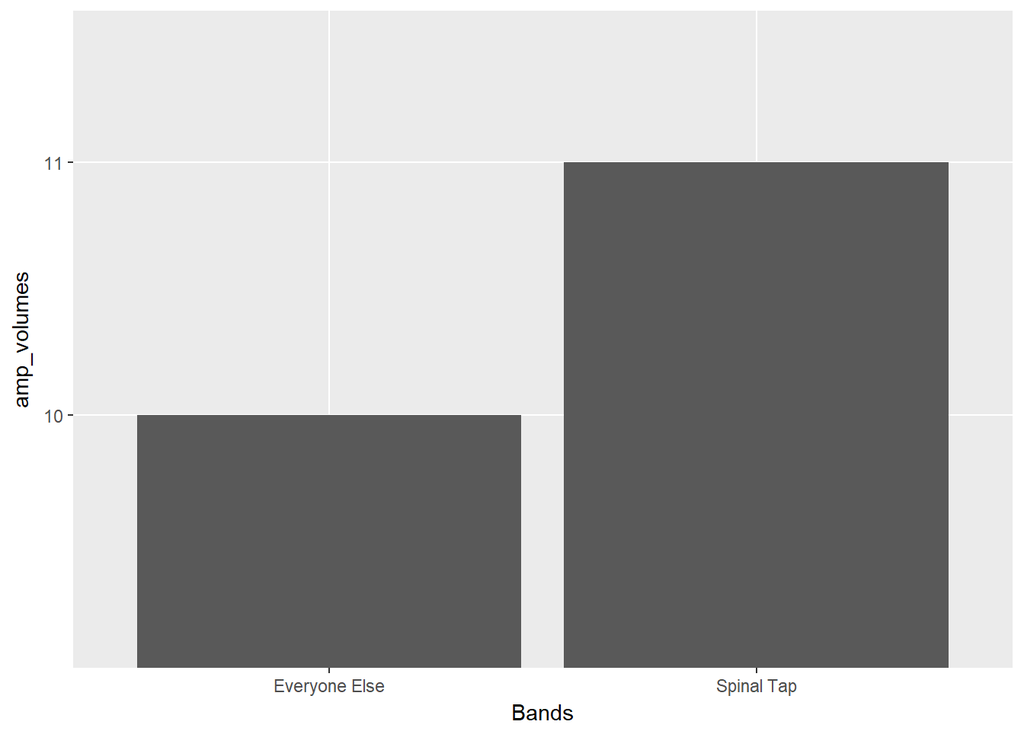

```r
ggplot(data=amp_volume_dataframe, aes(x=Bands, y = amp_volumes))+
  geom_col()
```

It worked! We’ll spend some time talking about ggplot (led by Jonny) a little later on, so don’t worry about what that code means. Soon you’ll know.

One more thing, say we are confused about how a package works. We can google it (and you should) and we can also use R’s built in help. To access the help file of a function, you enter a ‘?’ followed by the package name:

```r
?ggplot
```

```
## starting httpd help server ... done
```

The help documentation can be pretty confusing if you aren’t quite familiar with the package/function. The examples (which are typically at the bottom) can be very helpful, even for begginers. And some are simpler than others:

```r
?sqrt
```

See, this one basically just says it computes square root of x, where x is a vector or array. It also tells you (subtly) what the function works with; square root expects a numerical vector (including a vector of 1, or an element). If we give it a vector of non-number objects (like the Bands list above), it won’t work. Sometimes checking the help documentation can tell you if you’ve given the function the wrong type of object.

## Some more useful basic syntax

We’ve covered some of the basics of R syntax (e.g., the assignment operator ‘<-’)

Here are a few more aspects of R syntax that are helpful to keep in mind

- R is case sensitive. So a and A would be two different objects
  - A very common syntax mistake is using the wrong case (e.g., you assigned an object to a, and try to call it with A)
- R is newline terminated, meaning that things on the same line are considered a single statement. However, if a statement is incomplete (e.g., ends in an open parenthesis, or ends with a comma), R will search on the next line for the resolution. See the example below

```r
# Create 2 example vectors
example_part1 <- runif(100)
example_part2 <- runif(100)

# All three of these are equivalent:

example <- cbind(example_part1, example_part2)
example <- cbind(example_part1,
            example_part2)
example <- cbind(example_part1
            ,example_part2)
```

- You can typically subset objects using []. If the object is a matrix (i.e., has rows and columns), the argument order is [rows, columns]. If the object is a vector, then only one number goes in the bracket [rows]. Here are some examples of subsetting the example object from above
  - example[1:50,]
    - This would give us the first 50 rows, and all columns
  - example[1:50, 1]
    - This would give us the first 50 rows and just the first column
  - example[,1]
    - This would give us all rows, just the first column
- If you are using logical statements, you use “==” for is equal to. So, if we wanted to see if any elements in example is equal to 1, we would use the following:
  - example == 1
    - This would provide us with an object the same dimensions as example, with TRUE or FALSE in every cell, where TRUE means the value in the cell was equal to 1 and FALSE means the value in the cell was not equal to 1.
  - One reason for this is that ‘=’ can be used as an assignment operator (it is equivalent to ‘<-’) and is also used in defining arguments in functions (e.g., instead of sqrt(example) we could write sqrt(x=example) because the first argument in sqrt is called x, so we can use an ‘=’ to define it).
- Some other logical statements:
  - “==” means is equal to (from above)
  - “!=” means not equal to
  - “>” means greater than
  - “<” means less than
  - “<=” means less than or equal to
  - “>=” means greater than or equal to

That is all for this basic overview of R. Hopefully it has started to make youR adventuRe moRe toleRable!